# Chapter 3 - The Student Alcohol Consumption Dataset - Visualization and Analysis

Gyan Dookie

10 February 2017

## Chapter 3 - The Student Alcohol Consumption Dataset - Tabulation, visualization and Analysis

##### In this exercise I’ll be using the *Data Mining To Predict Secondary School Student Alcohol Consumption* -data that was created by Fabio Pagnotta, Hossain Mohammad Amran (Department of Computer Science,University of Camerino) in 2008. The data contains two identical questionnaires related to secondary school students’ alcohol consumption in Portugal. The two surveyed groups were 1) the students of Math course (Gabriel Pereira school) and 2) the students of the Portuguese language course (Mousinho da Silveira school).

### 1. Read the data into R

Here we read the joined student alcohol consumption data into R ( *Remember that the path to the .csv file must be relative in order for it to work on the remote server!*).

```r
alc <- read.table("data/alc_mod.csv", header= TRUE, sep=",")
alc_orig <- alc
```

### 2. Preliminary explorations of the data

The combined dataset’s 35 variables are shown below and it has altogether 382 observations (rows)

```
##  [1] "school"     "sex"        "age"        "address"    "famsize"
##  [6] "Pstatus"    "Medu"       "Fedu"       "Mjob"       "Fjob"
## [11] "reason"     "nursery"    "internet"   "guardian"   "traveltime"
## [16] "studytime"  "failures"   "schoolsup"  "famsup"     "paid"
## [21] "activities" "higher"     "romantic"   "famrel"     "freetime"
## [26] "goout"      "Dalc"       "Walc"       "health"     "absences"
## [31] "G1"         "G2"         "G3"         "alc_use"    "high_use"
```

```
## [1] 382  35
```

The data includes the following variable datatypes: factorial, integer, numeric and logical. I used the pipe symbol to provide the output of the head()-function (prints out the observations according to the given second parameter) to the str()-function that shows the structure of the data.

```r
head(alc, 0) %>% str()
```

```
## 'data.frame':    0 obs. of  35 variables:
##  $ school    : Factor w/ 2 levels "GP","MS":
##  $ sex       : Factor w/ 2 levels "F","M":
##  $ age       : int
##  $ address   : Factor w/ 2 levels "R","U":
##  $ famsize   : Factor w/ 2 levels "GT3","LE3":
##  $ Pstatus   : Factor w/ 2 levels "A","T":
##  $ Medu      : int
##  $ Fedu      : int
##  $ Mjob      : Factor w/ 5 levels "at_home","health",..:
##  $ Fjob      : Factor w/ 5 levels "at_home","health",..:
##  $ reason    : Factor w/ 4 levels "course","home",..:
##  $ nursery   : Factor w/ 2 levels "no","yes":
##  $ internet  : Factor w/ 2 levels "no","yes":
##  $ guardian  : Factor w/ 3 levels "father","mother",..:
```

[output cut: 21 more lines]

### 3. My personal hypothesis of the relationships between high/low alcohol usage and 4 other variables

Next I’m gonna present my hypothesis of the relationships between high/low alcohol use and four other variables I chose from the data: sex, study time, internet use and the final grade for the course

- **Sex vs. high/low alcohol use**
  - I believe that the male gender uses more alcohol than the female gender. I base this assumption on cultural aspects. The survey was conducted in Portugal where the gender roles are, I assume, more traditional and conservative than in Finland. I think (in Portugal) there’s more social pressure towards women to “behave” and not be shown drunk in the public than towars men. My hypothesis is that here is a strong positive correlation between the male gender and high alcohol use.
- **Study time vs. high/low alcohol use**
  - My hypothesis here is based on a simple assumption. The more you use alcohol, the more you are doing something else than studying (i.e. hanging out in the bar with your friends). And let’s face it, if you are drunk, it is quite difficult to study. That said, my hypothesis is that study time is negatively correlated to high alcohol use.
- **Internet use vs. high/low alcohol use**
  - This relationship is not so easy to hypothesize. I just assumed above that when you’re using alcohol, you are likely to hang out with your friends. It would be also difficult to concentrate on cognitively challenging tasks. The mobile internet usage could be a game changer here, because many younger people nowadays use internet all the time through the mobile devices (e.g. when hanging out with their friends). Nevertheless, the survey’s factorial internet variable means the internet at home. That being the case, internet connection only at home might reduce hanging out and so the use of alcohol. There’s also a psychological point that could affect this relationship. High alcohol use and high internet use might be a sign that the person is oriented towards crossing virtual, technological, social and psychological “borders”" and exploring the unknown. The former (you don’t hangout because your at home using your internet connection) and the latter (heavy internet and alcohol users have the same kind of “crossing borders” mindset) seem to cancel each other out. So my hypothesis is that there is a close to zero correlation between high internet use and high alcohol consumption.
- **Final course grade vs. high alcohol consumption**
  - Moderate alcohol use usually predicts longer life than no alcohol use, so there’s some connection, I guess, between the former and cognitive stamina. Nevertheless my hypothesis here is that high alcohol consumption results in lower final course grades. If you drink too much you will likely have more school absences and you will not be able to concentrate on cognitively challenging things. The correlation here would be negative and statistically significant

### 4. Exploring the distributions of my chosen variables numerically and graphically

#### **4.1 Summary statistics of sex, high alcohol use and how these affect the mean of the final grade**

```
## Source: local data frame [4 x 4]
## Groups: sex [?]
##
##      sex high_use count mean_grade
##   <fctr>    <lgl> <int>      <dbl>
## 1      F    FALSE   156   11.39744
## 2      F     TRUE    42   11.71429
## 3      M    FALSE   112   12.20536
## 4      M     TRUE    72   10.27778
```

This summary indicates that high alcohol use affects more the mean final grade of males than the mean final grade of females.

#### **4.2 Visualizations**

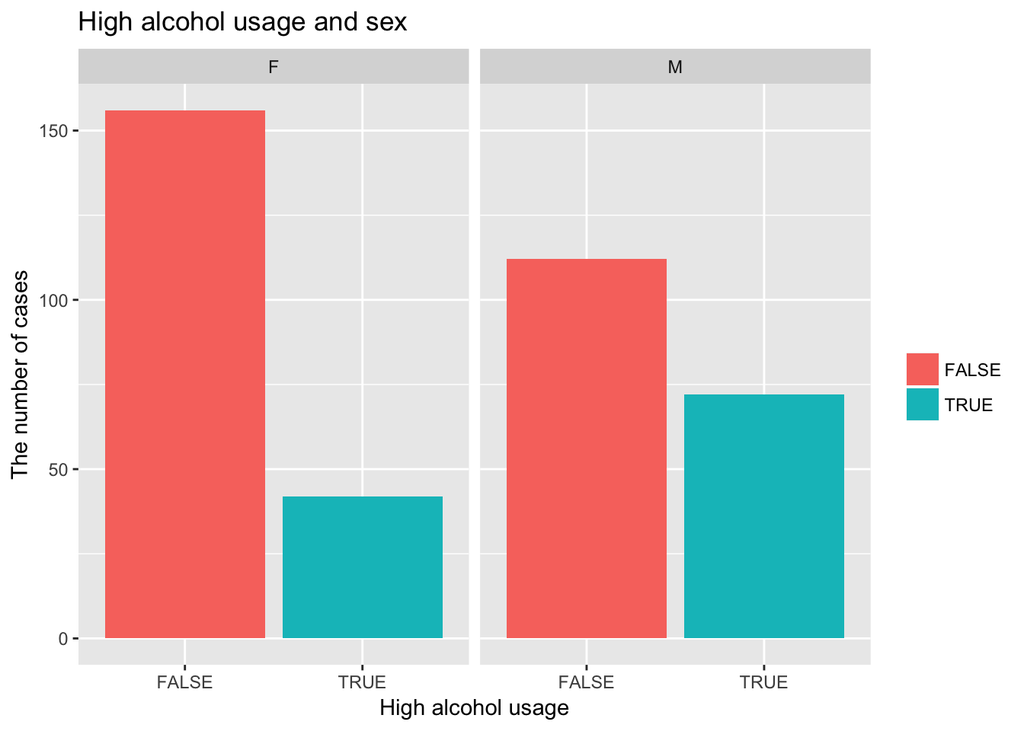

From the barplot above we can also see, that high alcohol use and sex are somehow connected

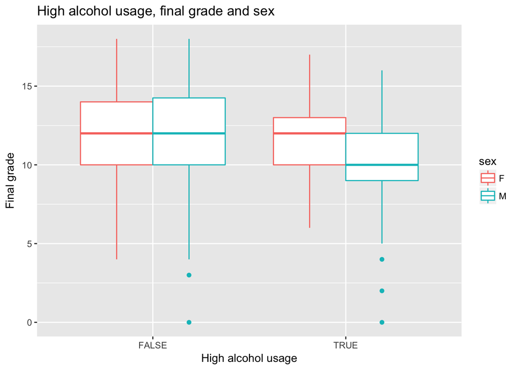

The boxplots above indicates that high use of alcohol has a more negative effect on the final grades of males than the final grades of females. The final grade mean of heavy drinking men drops considerably when compared with heavy drinking women.

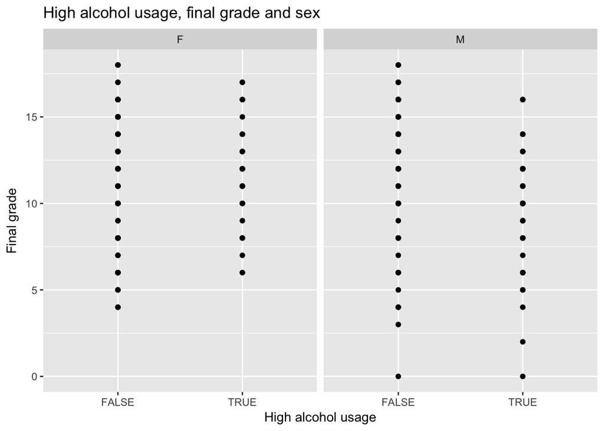

A different, point visualization of high alcohol usage, final grade and sex indicates the same (male alcohol usage affects more negatively the final grade than womens’ alcohol usage)

#### **4.3 Summary statistics of internet at home, high alcohol usage and how these affect the final grade**

Producing summary statistics by group

```
## Source: local data frame [4 x 4]
## Groups: internet [?]
##
##   internet high_use count mean_grade
##     <fctr>    <lgl> <int>      <dbl>
## 1       no    FALSE    43  10.883721
## 2       no     TRUE    15   9.933333
## 3      yes    FALSE   225  11.897778
## 4      yes     TRUE    99  10.939394
```

The summary statistics above indicates that internet at home and low alcohol usage has a positive effect on the final grade.

#### **4.4 Visualizations**

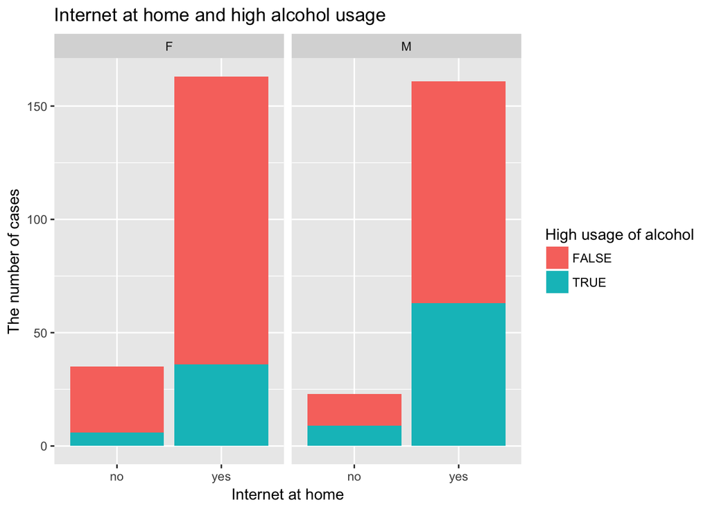

It looks like internet at home has no statistically important effect on the use of alcohol.

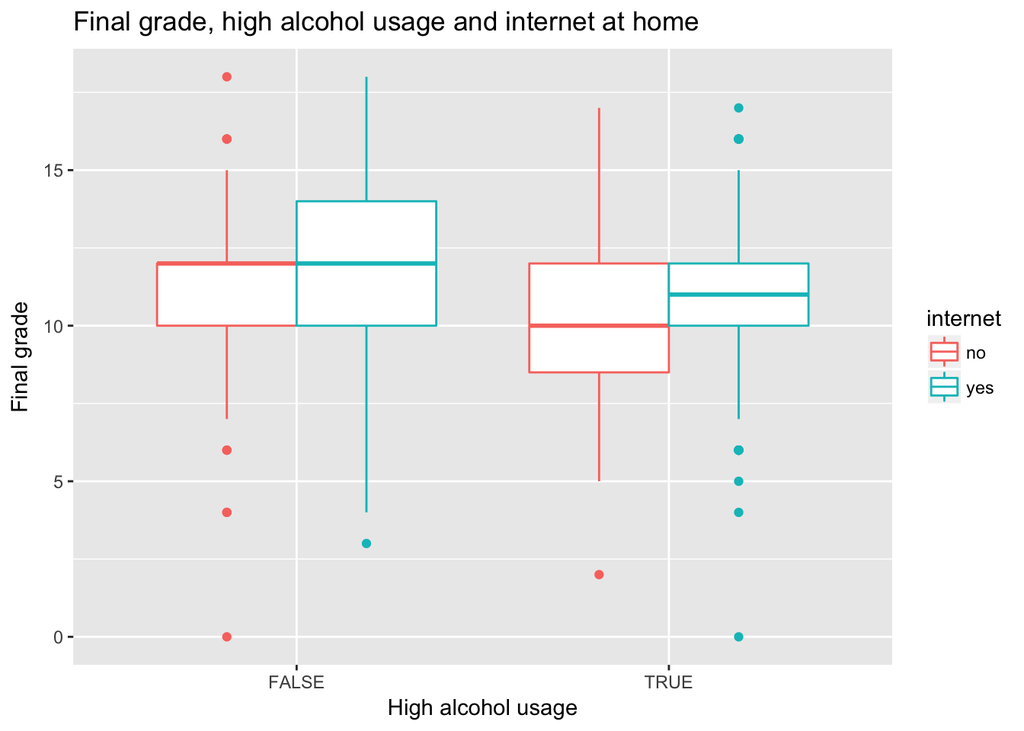

#### **4.5 Summary statistics of studytime, high alcohol use and how these affect the mean of the final grade**

Producing summary statistics by group

```
## Source: local data frame [8 x 4]
## Groups: studytime [?]
##
##   studytime high_use count mean_grade
##       <int>    <lgl> <int>      <dbl>
## 1         1    FALSE    58   10.84483
## 2         1     TRUE    42   10.38095
## 3         2    FALSE   135   11.75556
## 4         2     TRUE    60   10.70000
## 5         3    FALSE    52   12.42308
## 6         3     TRUE     8   13.00000
## 7         4    FALSE    23   12.30435
## 8         4     TRUE     4   12.50000
```

The above summary statistics revealed something quite surprising. The combination of long study time and high alchohol usage seems to produce better final grades than other combinations.

#### **4.6 Visualizations**

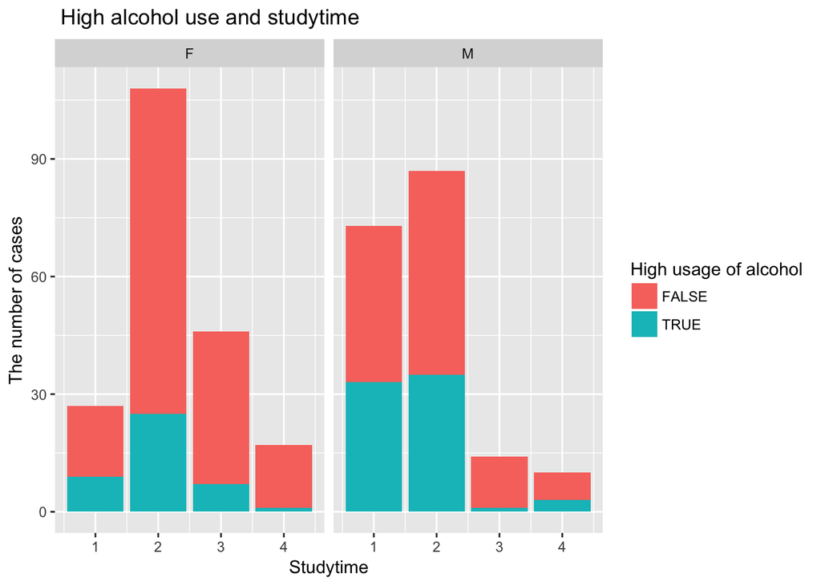

The barplot above indicates that for women the highest studytime and for men the second highest studytime means the proprotionally lowest alcohol usage (in relation to high usage).

### 5. Exploring the relationship between my chosen variables and the binary high/low alcohol consumption variable with logistic regression

#### **5.1 The summary and the coefficients of the model**

Next we’ll use glm() to *fit a logistic regression model* with high_use as the target variable and sex, internet, studytime and the final grade (G3) as the predictors. Then we’ll print out **the summary of the model** and finally **the coefficients of the model**.

*The summary of the model*

The fitted logistic regression model below shows the following.

- The estimate indicates that male sex has a considerable positive correlation with high alcohol usage and so predicts alcohol usage
- Final grade and alcohol usage have minimal correlation
- Internet at home has a slight positive correlation with alcohol usage
- Studytime has a noticeable negative correlation with alcohol usage

```
##
## Call:
## glm(formula = high_use ~ sex + internet + studytime + G3, family = "binomial",
##     data = alc)
##
## Deviance Residuals:
##     Min       1Q   Median       3Q      Max
## -1.4103  -0.8419  -0.6579   1.1690   2.2315
##
## Coefficients:
##             Estimate Std. Error z value Pr(>|z|)
## (Intercept)  0.21682    0.55421   0.391  0.69563
## sexM         0.67755    0.24420   2.775  0.00553 **
## internetyes  0.29328    0.33791   0.868  0.38544
## studytime   -0.43538    0.15902  -2.738  0.00618 **
## G3          -0.07324    0.03582  -2.045  0.04087 *
## ---
## Signif. codes:  0 '***' 0.001 '**' 0.01 '*' 0.05 '.' 0.1 ' ' 1
##
## (Dispersion parameter for binomial family taken to be 1)
##
##     Null deviance: 465.68  on 381  degrees of freedom
## Residual deviance: 436.00  on 377  degrees of freedom
## AIC: 446
##
## Number of Fisher Scoring iterations: 4
```

*The coefficients of the model*

```
## (Intercept)        sexM internetyes   studytime          G3
##  0.21682330  0.67754602  0.29328036 -0.43538191 -0.07323889
```

#### **5.2 Computing the odd ratios of the coefficients and providing the confidence intervals for them**

The computational target variable in the logistic regression model is the log of odds. That is why the exponents of the coefficients of a logistic regression model can be interpret as odds ratios between a unit change (vs no change) in the corresponding explanatory variable.

```
## (Intercept)        sexM internetyes   studytime          G3
##   1.2421246   1.9690398   1.3408186   0.6470175   0.9293788
```

Let’s print out the odd ratios binded together with their confidence intervals!

```
##                    OR     2.5 %    97.5 %
## (Intercept) 1.2421246 0.4173118 3.6917548
## sexM        1.9690398 1.2229494 3.1911181
## internetyes 1.3408186 0.7044930 2.6702180
## studytime   0.6470175 0.4694243 0.8771147
## G3          0.9293788 0.8656554 0.9965402
```

From these confidence intervals we can conclude the following.

- The connection between male sex and high alcohol usage has the widest confidence interval (at 97,5 %) and so the estimate is the least accurate
- The estimates indicating studytime’s and final grade’s relation to high alcohol usage have the tightest confidence intervals and so their estimates are the most accurate
- The accuracy of the estimate of the relation between internet at home and alcohol confidence interval is slightly smaller than the male sex : alcohol usage confidence interval

The reasons why the confidence interval indicating the accuracy of the sex : alcohol usage -estimate is the widest could include the following:

- The students might not want to tell the truth about their alcohol usage in the survey
- Alcohol usage might vary periodically

### 6. Exploring the predictive power of the model

```
##         prediction
## high_use FALSE
##    FALSE   268
##    TRUE    114
```

```
## [1] 382  37
```

```
## [1] 70.15707
```

```
##         prediction
## high_use     FALSE       Sum
##    FALSE 0.7015707 0.7015707
##    TRUE  0.2984293 0.2984293
##    Sum   1.0000000 1.0000000
```

**Conclusions**